# TP MPDW Pert 3

NIda Khairunnissa

2025-09-11

## Pemilihan Variabel

Kualitas udara merupakan salah satu isu lingkungan yang paling dekat dengan kehidupan masyarakat sehari-hari. Indeks Kualitas Udara (Air Quality Index/AQI) banyak digunakan sebagai indikator sederhana untuk menilai apakah udara yang dihirup aman atau berbahaya bagi kesehatan. Dalam data yang tersedia, AQI dipengaruhi oleh berbagai polutan seperti CO, NO₂, O₃, PM₁₀, PM₂.₅, dan SO₂. Dari sekian banyak variabel, PM₂.₅ (particulate matter dengan diameter ≤ 2.5 µm) dipilih sebagai fokus analisis karena partikelnya sangat kecil sehingga mudah masuk ke dalam sistem pernapasan dan aliran darah, serta secara langsung berkaitan dengan peningkatan risiko penyakit pernapasan maupun kardiovaskular. Selain itu, PM₂.₅ juga merupakan komponen utama dalam perhitungan AQI menurut standar WHO dan US EPA, sehingga pemantauannya sangat penting.

## Tujuan Analisis

Analisis ini dilakukan untuk memodelkan bagaimana nilai AQI ($Y_t$) dipengaruhi oleh variabel bebas ($X$), baik dari nilai saat ini maupun dari nilai masa lalunya ($X_{t-1}, X_{t-2}, \dots$), serta mempertimbangkan pengaruh nilai masa lalu dari AQI itu sendiri ($Y_{t-1}, Y_{t-2}, \dots$). Beberapa metode deret waktu yang akan diterapkan meliputi model Koyck, Distributed Lag Model (DLM), dan Autoregressive Distributed Lag (ARDL) yang nantinya akan ditentukan metode terbaik yang mampu menggambarkan hubungan jangka pendek maupun jangka panjang antara PM₂.₅ dan AQI.

## Packages

```r
#PACKAGES
library(dLagM)
library(dynlm)
library(MLmetrics)
library(lmtest)
library(car)
```

## Input Data

```r
data <- rio::import("https://raw.githubusercontent.com/nida-kha44/MPDW/refs/heads/main/NewDelhi_Air_quality.csv")
str(data)
```

```
## 'data.frame':    72 obs. of  12 variables:
##  $ V1             : int  0 1 2 3 4 5 6 7 8 9 ...
##  $ AQI            : num  30.2 28.2 26.6 25 26 26 26 24 23 24 ...
##  $ CO             : num  199 198 199 202 205 ...
##  $ datetime       : chr  "2022-10-21:18" "2022-10-21:19" "2022-10-21:20" "2022-10-21:21" ...
##  $ no2            : num  0.0469 0.0465 0.0469 0.0482 0.0489 ...
##  $ o3             : num  55.8 54.9 54.6 55.1 55.8 ...
##  $ pm10           : num  10.5 10.7 11.2 11.1 10.4 ...
##  $ pm25           : num  5.64 4.62 3.52 2.23 1.98 ...
##  $ so2            : num  0.387 0.41 0.402 0.376 0.339 ...
##  $ timestamp_local: POSIXct, format: "2022-10-21 23:00:00" "2022-10-22 00:00:00" ...
##  $ timestamp_utc  : POSIXct, format: "2022-10-21 18:00:00" "2022-10-21 19:00:00" ...
##  $ ts             : int  1666375200 1666378800 1666382400 1666386000 1666389600 1666393200 1666396800 1666400400 1666404000 1666407600 ...
```

```r
data
```

```
##    V1  AQI       CO      datetime        no2       o3      pm10     pm25
## 1   0 30.2 198.6027 2022-10-21:18 0.04685717 55.78995 10.486722 5.637410
## 2   1 28.2 197.6013 2022-10-21:19 0.04645554 54.93164 10.719325 4.618169
## 3   2 26.6 198.6027 2022-10-21:20 0.04685717 54.64554 11.155578 3.520902
## 4   3 25.0 201.9405 2022-10-21:21 0.04819594 55.07469 11.116206 2.225919
## 5   4 26.0 205.2784 2022-10-21:22 0.04886533 55.78995 10.405250 1.979471
## 6   5 26.0 208.6163 2022-10-21:23 0.05020411 56.50520  9.402518 1.792677
## 7   6 26.0 208.6163 2022-10-22:00 0.05020411 55.78995  8.482822 1.752237
## 8   7 24.0 205.2784 2022-10-22:01 0.05020411 52.92892  7.586667 1.858459
## 9   8 23.0 200.2716 2022-10-22:02 0.04685717 50.06790  7.636587 2.208076
## 10  9 24.0 196.9338 2022-10-22:03 0.04417961 51.49841  8.487648 2.476681
## 11 10 25.0 198.6027 2022-10-22:04 0.04284084 53.64418  9.357371 2.585729
## 12 11 26.0 200.2716 2022-10-22:05 0.04049798 55.78995 10.338728 2.390081
## 13 12 27.0 203.6095 2022-10-22:06 0.04016329 59.36623 10.523314 2.086022
## 14 13 29.0 205.2784 2022-10-22:07 0.03882451 62.22725 10.635970 1.937047
```

[output cut: 131 more lines]

## Eksplorasi

```r
# 2. Lihat struktur data
str(data)
```

```
## 'data.frame':    72 obs. of  12 variables:
##  $ V1             : int  0 1 2 3 4 5 6 7 8 9 ...
##  $ AQI            : num  30.2 28.2 26.6 25 26 26 26 24 23 24 ...
##  $ CO             : num  199 198 199 202 205 ...
##  $ datetime       : chr  "2022-10-21:18" "2022-10-21:19" "2022-10-21:20" "2022-10-21:21" ...
##  $ no2            : num  0.0469 0.0465 0.0469 0.0482 0.0489 ...
##  $ o3             : num  55.8 54.9 54.6 55.1 55.8 ...
##  $ pm10           : num  10.5 10.7 11.2 11.1 10.4 ...
##  $ pm25           : num  5.64 4.62 3.52 2.23 1.98 ...
##  $ so2            : num  0.387 0.41 0.402 0.376 0.339 ...
##  $ timestamp_local: POSIXct, format: "2022-10-21 23:00:00" "2022-10-22 00:00:00" ...
##  $ timestamp_utc  : POSIXct, format: "2022-10-21 18:00:00" "2022-10-21 19:00:00" ...
##  $ ts             : int  1666375200 1666378800 1666382400 1666386000 1666389600 1666393200 1666396800 1666400400 1666404000 1666407600 ...
```

```r
summary(data)
```

```
##        V1             AQI              CO          datetime
##  Min.   : 0.00   Min.   :19.00   Min.   :191.9   Length:72
##  1st Qu.:17.75   1st Qu.:25.00   1st Qu.:197.4   Class :character
##  Median :35.50   Median :27.00   Median :200.3   Mode  :character
##  Mean   :35.50   Mean   :26.18   Mean   :200.1
##  3rd Qu.:53.25   3rd Qu.:28.00   3rd Qu.:203.6
##  Max.   :71.00   Max.   :32.00   Max.   :208.6
##       no2                o3             pm10             pm25
##  Min.   :0.01556   Min.   :41.48   Min.   : 6.687   Min.   :1.633
##  1st Qu.:0.03799   1st Qu.:53.64   1st Qu.: 7.865   1st Qu.:1.829
##  Median :0.04552   Median :57.22   Median : 8.914   Median :2.202
##  Mean   :0.04200   Mean   :56.57   Mean   : 9.115   Mean   :2.295
##  3rd Qu.:0.05020   3rd Qu.:60.08   3rd Qu.:10.275   3rd Qu.:2.522
##  Max.   :0.06091   Max.   :68.66   Max.   :12.846   Max.   :5.637
##       so2         timestamp_local               timestamp_utc
##  Min.   :0.2831   Min.   :2022-10-21 23:00:00   Min.   :2022-10-21 18:00:00
##  1st Qu.:0.3204   1st Qu.:2022-10-22 16:45:00   1st Qu.:2022-10-22 11:45:00
##  Median :0.3725   Median :2022-10-23 10:30:00   Median :2022-10-23 05:30:00
##  Mean   :0.3634   Mean   :2022-10-23 10:30:00   Mean   :2022-10-23 05:30:00
##  3rd Qu.:0.3958   3rd Qu.:2022-10-24 04:15:00   3rd Qu.:2022-10-23 23:15:00
##  Max.   :0.4545   Max.   :2022-10-24 22:00:00   Max.   :2022-10-24 17:00:00
##        ts
##  Min.   :1.666e+09
##  1st Qu.:1.666e+09
##  Median :1.667e+09
##  Mean   :1.667e+09
##  3rd Qu.:1.667e+09
##  Max.   :1.667e+09
```

```r
# 3. Cek missing value
colSums(is.na(data))
```

```
##              V1             AQI              CO        datetime             no2
##               0               0               0               0               0
##              o3            pm10            pm25             so2 timestamp_local
##               0               0               0               0               0
##   timestamp_utc              ts
##               0               0
```

```r
# 4. Statistik deskriptif variabel numerik
library(psych)
describe(data[, c("AQI","CO","no2","o3","pm10","pm25","so2")])
```

```
##      vars  n   mean   sd median trimmed  mad    min    max range  skew kurtosis
## AQI     1 72  26.18 3.05  27.00   26.31 2.97  19.00  32.00 13.00 -0.41    -0.18
## CO      2 72 200.10 4.52 200.27  200.14 4.95 191.93 208.62 16.69  0.00    -0.72
## no2     3 72   0.04 0.01   0.05    0.04 0.01   0.02   0.06  0.05 -0.86    -0.16
## o3      4 72  56.57 6.43  57.22   56.81 5.30  41.48  68.66 27.18 -0.39    -0.17
## pm10    5 72   9.12 1.53   8.91    9.04 1.74   6.69  12.85  6.16  0.37    -0.55
## pm25    6 72   2.30 0.66   2.20    2.20 0.55   1.63   5.64  4.00  2.50     8.99
## so2     7 72   0.36 0.04   0.37    0.36 0.05   0.28   0.45  0.17  0.16    -0.95
##        se
## AQI  0.36
## CO   0.53
## no2  0.00
## o3   0.76
## pm10 0.18
## pm25 0.08
## so2  0.01
```

```r
# 5. Korelasi dengan AQI
cor(data$AQI, data$CO, use="complete.obs")
```

```
## [1] 0.7976332
```

```r
cor_matrix <- cor(data[, c("AQI","CO","no2","o3","pm10","pm25","so2")], use="complete.obs")
cor_matrix
```

```
##              AQI          CO        no2          o3        pm10       pm25
## AQI   1.00000000  0.79763320  0.7376547  0.97359901  0.08257568 -0.3466552
## CO    0.79763320  1.00000000  0.6520228  0.82919809 -0.09598578 -0.5829151
## no2   0.73765472  0.65202279  1.0000000  0.73204188  0.25652368 -0.3588091
## o3    0.97359901  0.82919809  0.7320419  1.00000000  0.03381079 -0.5219779
## pm10  0.08257568 -0.09598578  0.2565237  0.03381079  1.00000000  0.2684827
## pm25 -0.34665524 -0.58291511 -0.3588091 -0.52197786  0.26848271  1.0000000
## so2  -0.74247813 -0.79872002 -0.5859130 -0.78562485 -0.04779446  0.6743428
##              so2
## AQI  -0.74247813
## CO   -0.79872002
## no2  -0.58591304
## o3   -0.78562485
## pm10 -0.04779446
## pm25  0.67434283
## so2   1.00000000
```

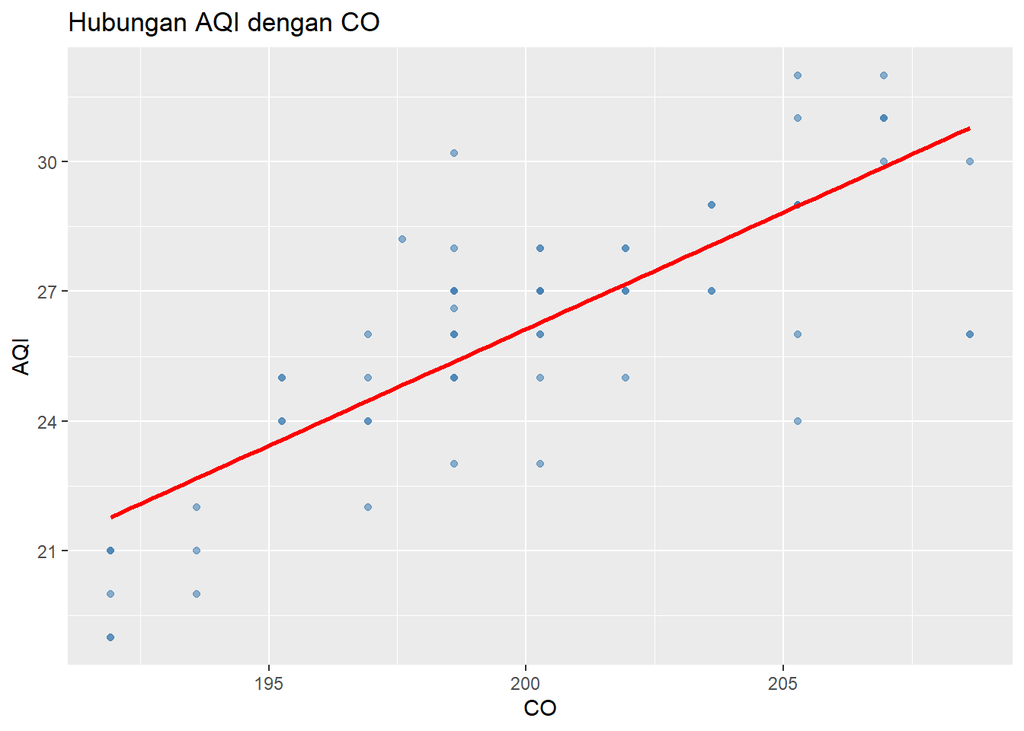

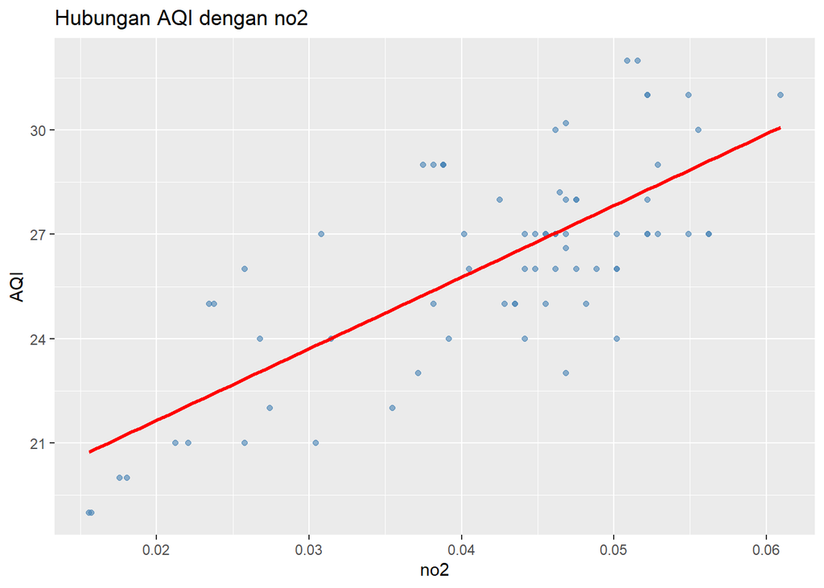

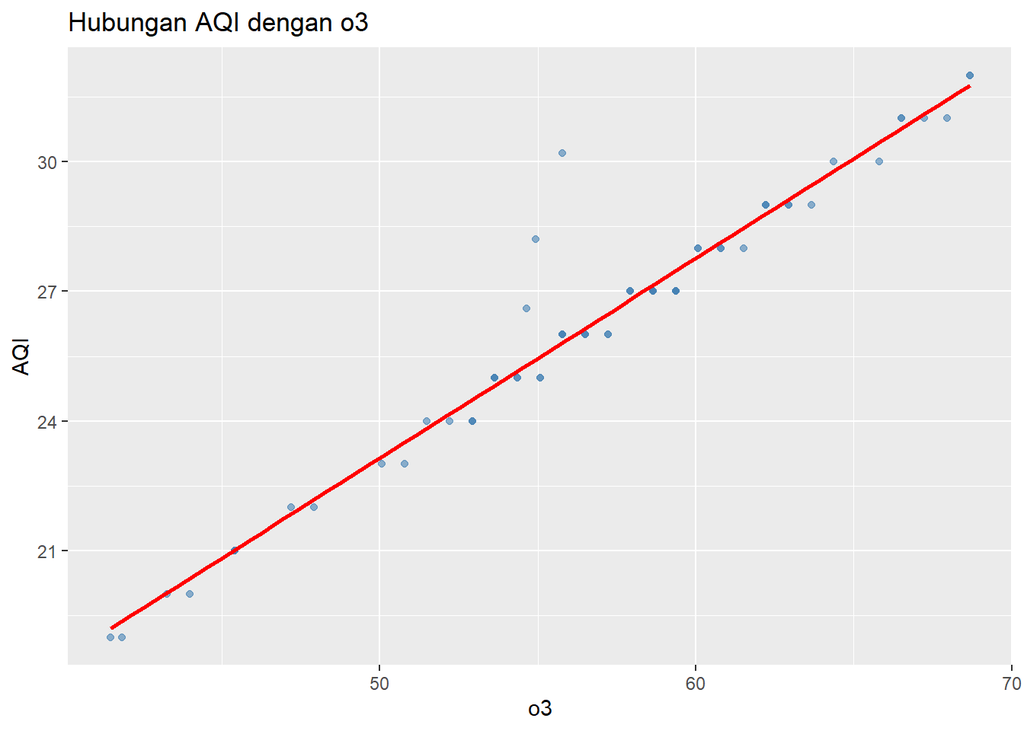

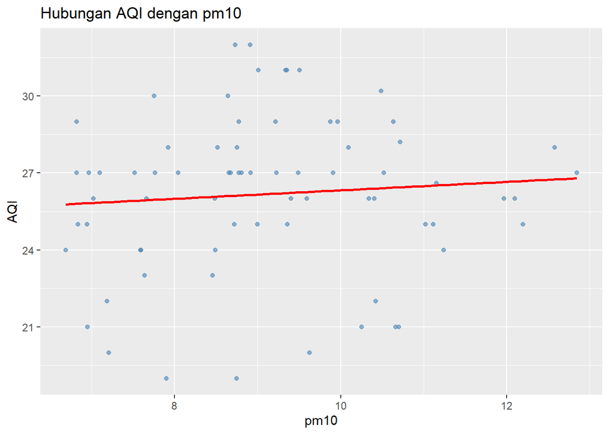

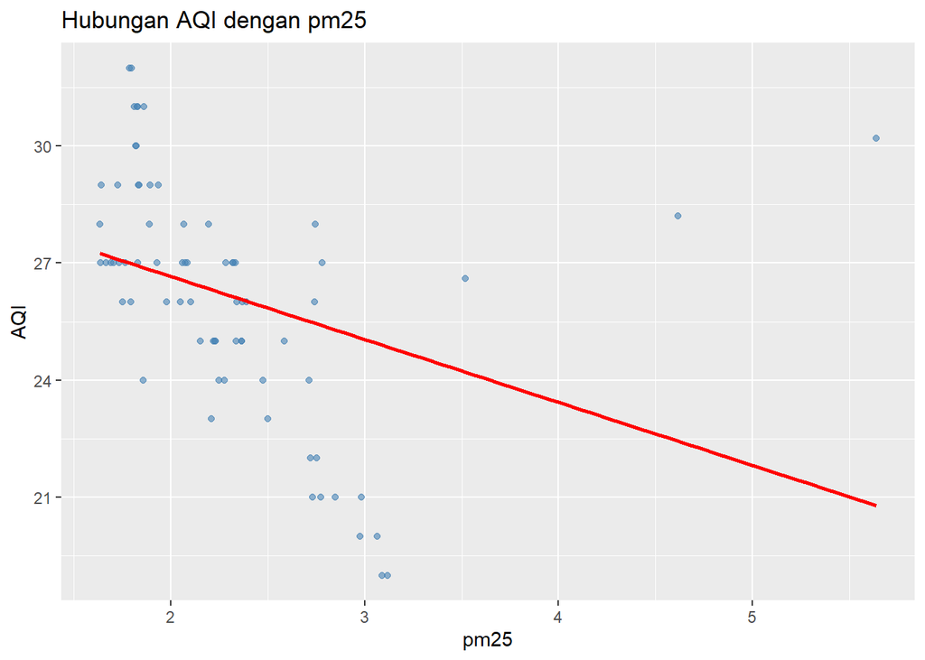

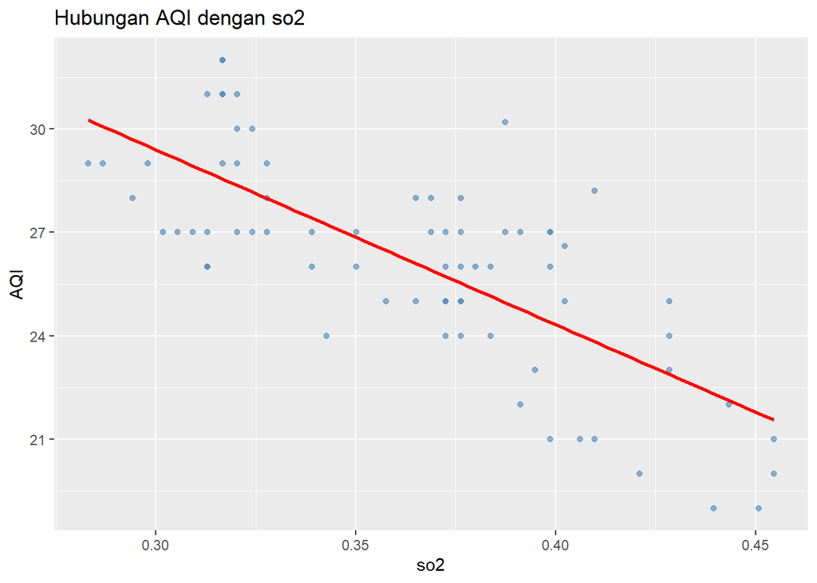

```r
# 6. Plot hubungan AQI dengan variabel numerik lain
library(ggplot2)
# Scatterplot untuk semua variabel
num_vars <- c("CO","no2","o3","pm10","pm25","so2")
for (var in num_vars) {
  print(
    ggplot(data, aes_string(x=var, y="AQI")) +
      geom_point(alpha=0.6, color="steelblue") +
      geom_smooth(method="lm", se=FALSE, color="red") +
      labs(title=paste("Hubungan AQI dengan", var),
           x=var, y="AQI")
  )
}
```

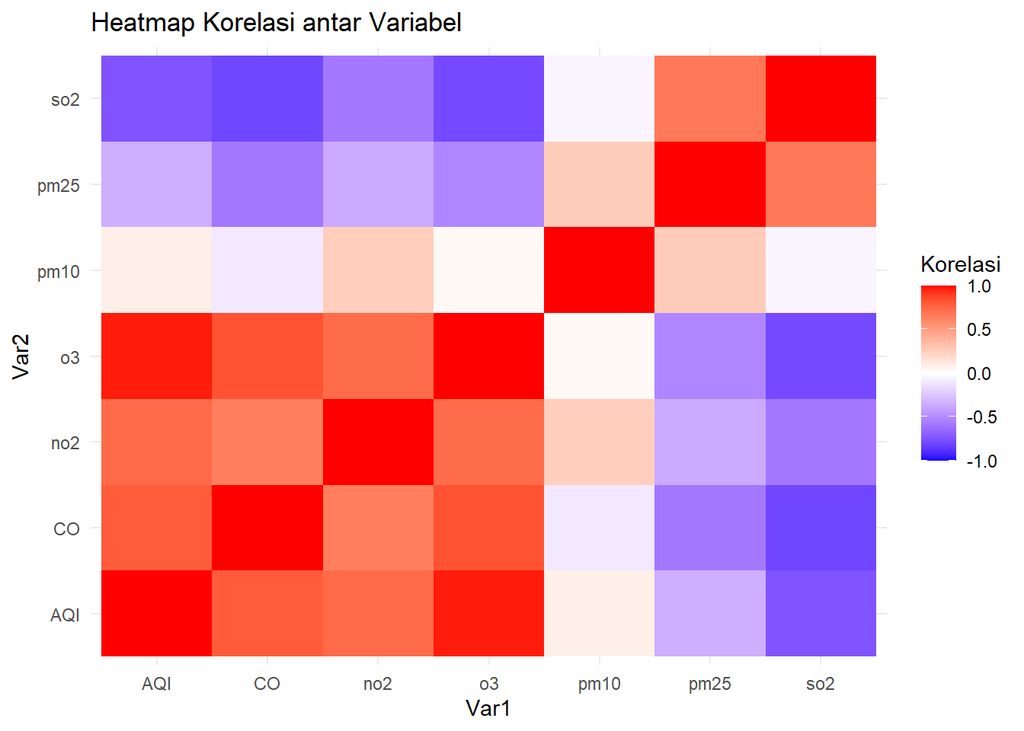

```r
# 7. Heatmap korelasi biar gampang lihat pola
library(reshape2)
melted_corr <- melt(cor_matrix)

ggplot(melted_corr, aes(x=Var1, y=Var2, fill=value)) +
  geom_tile() +
  scale_fill_gradient2(low="blue", high="red", mid="white",
                       midpoint=0, limit=c(-1,1), space="Lab",
                       name="Korelasi") +
  theme_minimal() +
  labs(title="Heatmap Korelasi antar Variabel")
```

Dari visualisasi scatter plot antara AQI dan PM2.5, terlihat adanya pola hubungan negatif di mana kenaikan konsentrasi PM2.5 cenderung diikuti dengan penurunan kualitas indeks udara (AQI). Hal ini relevan karena AQI memang dirancang sebagai indikator kualitas udara yang dipengaruhi langsung oleh polutan-partikulat, salah satunya PM2.5. Dengan demikian, pemilihan variabel AQI sebagai variabel dependen dan PM2.5 sebagai variabel independen didukung secara teoritis maupun empiris, mengingat PM2.5 merupakan salah satu kontributor utama penurunan kualitas udara di perkotaan.

## Input Data Terpilih

```r
dataaqi <- rio::import("https://raw.githubusercontent.com/nida-kha44/MPDW/refs/heads/main/Pertemuan%203/Data%20AQI-PM2.5.csv")
str(dataaqi)
```

```
## 'data.frame':    72 obs. of  4 variables:
##  $ t      : int  1 2 3 4 5 6 7 8 9 10 ...
##  $ Y_t    : num  30.2 28.2 26.6 25 26 26 26 24 23 24 ...
##  $ Y_(t-1): num  NA 30.2 28.2 26.6 25 26 26 26 24 23 ...
##  $ X_t    : num  5.64 4.62 3.52 2.23 1.98 ...
```

```r
dataaqi
```

```
##     t  Y_t Y_(t-1)      X_t
## 1   1 30.2      NA 5.637410
## 2   2 28.2    30.2 4.618169
## 3   3 26.6    28.2 3.520902
## 4   4 25.0    26.6 2.225919
## 5   5 26.0    25.0 1.979471
## 6   6 26.0    26.0 1.792677
## 7   7 26.0    26.0 1.752237
## 8   8 24.0    26.0 1.858459
## 9   9 23.0    24.0 2.208076
## 10 10 24.0    23.0 2.476681
## 11 11 25.0    24.0 2.585729
## 12 12 26.0    25.0 2.390081
## 13 13 27.0    26.0 2.086022
## 14 14 29.0    27.0 1.937047
```

[output cut: 58 more lines]

## Pembagian Data

Pembagian data dengan 80% data sebagai data train dan 20% data sebagai data test. Proporsi ini dipilih karena dianggap seimbang antara kebutuhan model untuk belajar pola dari data dan kebutuhan evaluasi model dengan data yang belum pernah dilihat sebelumnya.

```r
#SPLIT DATA
train<-dataaqi[1:58,]
test<-dataaqi[59:72,]
```

```r
#data time series
train.ts<-ts(train)
test.ts<-ts(test)
data.ts<-ts(dataaqi)
```

## Model Koyck

Model Koyck adalah salah satu model regresi dinamis yang digunakan untuk menganalisis hubungan antara variabel independen (X) dan variabel dependen (Y) dengan adanya pengaruh lag (efek masa lalu). Secara matematis, Koyck menyederhanakan model yang memiliki tak hingga lag menjadi model yang jauh lebih simpel dengan memasukkan **lag dari variabel dependen** $(Y_{t−1})$ sebagai salah satu prediktor. $Y_{t−1}$ ini secara implisit sudah merangkum semua informasi dari lag X di masa lalu.

**Formula Umum:**

$$y_t=a(1-\lambda)+\beta_0X_t+\beta_1Z_t+\lambda Y_{t-1}+V_t$$

dengan
$$V_t=u_t-\lambda
u_{t-1}$$

Di mana $\lambda$ (koefisien dari $Y_{t−1}$) menunjukkan “tingkat peluruhan” atau seberapa cepat pengaruh masa lalu memudar.

### Pemodelan dengan Model Koyck

```r
#MODEL KOYCK
model.koyck <- koyckDlm(x = train$X_t, y = train$Y_t)
sumkoyck <- summary(model.koyck)
```

```
##
## Call:
## "Y ~ (Intercept) + Y.1 + X.t"
##
## Residuals:
##      Min       1Q   Median       3Q      Max
## -2.14443 -0.61319  0.03512  0.48195  2.18725
##
## Coefficients:
##             Estimate Std. Error t value Pr(>|t|)
## (Intercept)   4.0771     1.8299   2.228   0.0301 *
## Y.1           0.8897     0.0588  15.131   <2e-16 ***
## X.t          -0.5723     0.2854  -2.005   0.0500 *
## ---
## Signif. codes:  0 '***' 0.001 '**' 0.01 '*' 0.05 '.' 0.1 ' ' 1
##
## Residual standard error: 0.9279 on 54 degrees of freedom
## Multiple R-Squared: 0.8273,  Adjusted R-squared: 0.8209
## Wald test: 129.1 on 2 and 54 DF,  p-value: < 2.2e-16
##
## Diagnostic tests:
## NULL
##
##                             alpha       beta       phi
## Geometric coefficients:  36.94716 -0.5722988 0.8896496
```

```r
AIC(model.koyck)
```

```
## [1] 158.1481
```

```r
BIC(model.koyck)
```

```
## [1] 166.3203
```

Berdasarkan hasil estimasi model, persamaan yang terbentuk adalah

$$\hat{Y_t}=4.0771-0.5723X_t+0.8897Y_{t-1}$$

Koefisien Xt sebesar −0.5723 signifikan pada taraf 5%, yang berarti variabel X saat ini memiliki pengaruh negatif terhadap Y, yaitu setiap kenaikan satu satuan X akan menurunkan Y sebesar 0.57 satuan dalam jangka pendek, dengan asumsi faktor lain konstan. Selanjutnya, koefisien Y(t−1) sebesar 0.8897 signifikan pada taraf 1%, yang menunjukkan bahwa sekitar 89% variasi Y di periode sebelumnya terbawa ke periode saat ini. Dengan kata lain, model ini menangkap adanya efek keterlambatan (lag effect) yang cukup kuat. Nilai R^2 sebesar 0.8273 juga menunjukkan bahwa model dapat menjelaskan sekitar 82,7% variasi Y, sehingga model memiliki kemampuan penjelasan yang baik.

### Peramalan dan Akurasi

Berikut adalah hasil peramalan y untuk 14 periode kedepan menggunakan model koyck

```r
fore.koyck <- forecast(model = model.koyck, x=test$X_t, h=14)
fore.koyck
```

```
## $forecasts
##  [1] 22.96490 22.79987 22.60639 22.40415 22.24036 22.15991 22.16242 22.20757
##  [9] 22.27123 22.33380 22.39368 22.42982 22.44082 22.47014
##
## $call
## forecast.koyckDlm(model = model.koyck, x = test$X_t, h = 14)
##
## attr(,"class")
## [1] "forecast.koyckDlm" "dLagM"
```

```r
mape.koyck <- MAPE(fore.koyck$forecasts, test$Y_t)
mape.koyck #data test
```

```
## [1] 0.1054825
```

```r
#akurasi data training
GoF(model.koyck)
```

```
##              n       MAE          MPE       MAPE      sMAPE     MASE       MSE
## model.koyck 57 0.6909776 -0.001122737 0.02589331 0.02582947 1.040181 0.8157075
##                  MRAE    GMRAE
## model.koyck 757377131 11372.75
```

## Regression with Distributed Lag

Regression with Distributed Lag (DLM) adalah model regresi yang digunakan ketika pengaruh suatu variabel bebas (X) terhadap variabel terikat (Y) tidak terjadi sekaligus pada periode yang sama, melainkan terdistribusi (menyebar) ke beberapa periode berikutnya.

### *Lag* Optimum

Mencari panjang lag yang paling optimal berdasarkan kriteria informasi seperti **AIC (Akaike Information Criterion)**. AIC menyeimbangkan antara kecocokan model dengan kompleksitasnya.

```r
#penentuan lag optimum
finiteDLMauto(formula = Y_t ~ X_t,
              data = data.frame(train), q.min = 1, q.max = 10,
              model.type = "dlm", error.type = "AIC", trace = TRUE)
```

```
##    q - k    MASE      AIC      BIC    GMRAE   MBRAE R.Adj.Sq    Ljung-Box
## 10    10 1.72201 186.2653 210.5909 49688.22 0.71611  0.52879 1.423614e-08
## 9      9 1.85325 195.5979 218.2998 44081.17 0.73051  0.47894 5.052925e-09
## 8      8 1.88799 199.1205 220.1527 38823.62 0.66594  0.50264 2.075788e-10
## 7      7 1.84754 200.0655 219.3837 30520.82 0.62313  0.53206 5.330174e-10
## 6      6 1.73867 201.1051 218.6663 22650.85 0.56392  0.54223 4.524737e-10
## 5      5 1.75280 204.0813 219.8436 23085.14 1.65593  0.53463 6.980942e-10
## 4      4 1.85610 209.9314 223.8543 31881.26 0.72405  0.50086 2.767593e-09
## 3      3 2.13163 220.3167 232.3607 38604.33 0.77447  0.42645 1.445641e-09
## 2      2 2.18873 233.0605 243.1873 29920.77 0.56412  0.30506 1.907737e-06
## 1      1 2.28775 246.7199 254.8921 24669.65 0.75741  0.15281 5.737415e-09
```

Lag optimum = 10 karena memberikan keseimbangan terbaik (AIC/BIC terkecil + MASE kecil + R² adjusted cukup tinggi).

### Pemodelan (Lag=10)

```r
model.dlm <- dlm(x = train$X_t,y = train$Y_t , q = 10)
sumdlm <- summary(model.dlm)
```

```
##
## Call:
## lm(formula = model.formula, data = design)
##
## Residuals:
##     Min      1Q  Median      3Q     Max
## -2.8038 -0.8916 -0.1139  0.8262  2.9915
##
## Coefficients:
##             Estimate Std. Error t value Pr(>|t|)
## (Intercept)   39.894      2.184  18.264  < 2e-16 ***
## x.t          -15.772      5.197  -3.035  0.00445 **
## x.1            7.398     12.991   0.569  0.57259
## x.2            6.854     16.729   0.410  0.68445
## x.3           -2.024     16.055  -0.126  0.90037
## x.4            1.510     15.044   0.100  0.92063
## x.5          -10.589     14.301  -0.740  0.46381
## x.6           19.702     12.033   1.637  0.11028
## x.7          -16.886      6.743  -2.504  0.01693 *
## x.8            1.674      4.389   0.381  0.70509
## x.9            6.618      4.381   1.511  0.13962
## x.10          -4.613      2.042  -2.259  0.03004 *
## ---
## Signif. codes:  0 '***' 0.001 '**' 0.01 '*' 0.05 '.' 0.1 ' ' 1
##
## Residual standard error: 1.483 on 36 degrees of freedom
## Multiple R-squared:  0.6391, Adjusted R-squared:  0.5288
## F-statistic: 5.795 on 11 and 36 DF,  p-value: 2.646e-05
##
## AIC and BIC values for the model:
##        AIC      BIC
## 1 186.2653 210.5909
```

```r
AIC(model.dlm)
```

```
## [1] 186.2653
```

```r
BIC(model.dlm)
```

```
## [1] 210.5909
```

Dari hasil di atas, didapat bahwa $P$-value dari intercept, $x_t$, $x_{t-7}$, dan $x_{t-10}$ lebih kecil dari 0.05. Hal ini menunjukkan bahwa keempat komponen tersebut berpengaruh signifikan terhadap $Y$. Dengan demikian, model keseluruhan yang terbentuk adalah:

$$\hat{Y_t}=39.894-15.772X_t-16.886X_{t-7}-4.613X_{t-10}$$
### Peramalan dan Akurasi

Berikut merupakan hasil peramalan $y$ untuk 14 periode kedepan

```r
fore.dlm <- forecast(model = model.dlm, x=test$X_t, h=14)
fore.dlm
```

```
## $forecasts
##  [1] 19.45431 20.79466 22.01949 21.85673 22.86199 25.71254 24.95044 25.21888
##  [9] 23.33608 23.52337 23.53436 22.05540 21.69674 23.23584
##
## $call
## forecast.dlm(model = model.dlm, x = test$X_t, h = 14)
##
## attr(,"class")
## [1] "forecast.dlm" "dLagM"
```

```r
mape.dlm <- MAPE(fore.dlm$forecasts, test$Y_t)
mape.dlm
```

```
## [1] 0.140921
```

```r
#akurasi data training
GoF(model.dlm)
```

```
##            n      MAE          MPE       MAPE      sMAPE     MASE      MSE
## model.dlm 48 1.025881 -0.002061215 0.03722007 0.03715434 1.722014 1.650344
##                 MRAE    GMRAE
## model.dlm 6182197513 49688.22
```

## Autoregressive Distributed Lag (ARDL)

Autoregressive Distributed Lag (ARDL) model adalah salah satu bentuk model regresi dinamis yang digunakan untuk menganalisis hubungan antara variabel dependen dengan variabel independen, baik dalam jangka pendek maupun jangka panjang.

### Pemodelan

Dengan $p$ adalah integer yang mewakili panjang *lag* yang terbatas dan $q$ adalah integer yang merepresentasikan ordo dari proses *autoregressive*.

```r
model.ardl <- ardlDlm(x = train$X_t, y = train$Y_t, p = 10 , q = 1)
summary(model.ardl)
```

```
##
## Time series regression with "ts" data:
## Start = 11, End = 58
##
## Call:
## dynlm(formula = as.formula(model.text), data = data, start = 1)
##
## Residuals:
##      Min       1Q   Median       3Q      Max
## -1.45082 -0.28283 -0.04545  0.45922  1.42850
##
## Coefficients:
##             Estimate Std. Error t value Pr(>|t|)
## (Intercept)  6.35244    2.95712   2.148  0.03870 *
## X.t         -8.10151    2.41351  -3.357  0.00191 **
## X.1          6.82518    5.81873   1.173  0.24873
## X.2          2.09430    7.50287   0.279  0.78179
## X.3          2.27771    7.19952   0.316  0.75360
## X.4         -6.14009    6.76774  -0.907  0.37047
## X.5          3.41654    6.51013   0.525  0.60303
## X.6          3.12373    5.56307   0.562  0.57803
## X.7         -7.45788    3.12008  -2.390  0.02235 *
## X.8          2.57333    1.96733   1.308  0.19939
## X.9          1.99415    1.99953   0.997  0.32546
## X.10        -1.79945    0.94408  -1.906  0.06489 .
## Y.1          0.85637    0.07125  12.019 5.59e-14 ***
## ---
## Signif. codes:  0 '***' 0.001 '**' 0.01 '*' 0.05 '.' 0.1 ' ' 1
##
## Residual standard error: 0.6644 on 35 degrees of freedom
## Multiple R-squared:  0.9296, Adjusted R-squared:  0.9055
## F-statistic: 38.52 on 12 and 35 DF,  p-value: < 2.2e-16
```

```r
AIC(model.ardl)
```

```
## [1] 109.8028
```

```r
BIC(model.ardl)
```

```
## [1] 135.9996
```

$$\hat{Y_t}=6.352-8.102X_t-7.458X_{t-7}-1.799X_{t-10}+0.856Y_{t-1}$$
### Peramalan dan Akurasi

```r
model.ardl <- ardlDlm(formula = Y_t ~ X_t, data = train, p = 10, q = 1)

sumardl <- summary(model.ardl)
```

```
##
## Time series regression with "ts" data:
## Start = 11, End = 58
##
## Call:
## dynlm(formula = as.formula(model.text), data = data)
##
## Residuals:
##      Min       1Q   Median       3Q      Max
## -1.45082 -0.28283 -0.04545  0.45922  1.42850
##
## Coefficients:
##             Estimate Std. Error t value Pr(>|t|)
## (Intercept)  6.35244    2.95712   2.148  0.03870 *
## X_t.t       -8.10151    2.41351  -3.357  0.00191 **
## X_t.1        6.82518    5.81873   1.173  0.24873
## X_t.2        2.09430    7.50287   0.279  0.78179
## X_t.3        2.27771    7.19952   0.316  0.75360
## X_t.4       -6.14009    6.76774  -0.907  0.37047
## X_t.5        3.41654    6.51013   0.525  0.60303
## X_t.6        3.12373    5.56307   0.562  0.57803
## X_t.7       -7.45788    3.12008  -2.390  0.02235 *
## X_t.8        2.57333    1.96733   1.308  0.19939
## X_t.9        1.99415    1.99953   0.997  0.32546
## X_t.10      -1.79945    0.94408  -1.906  0.06489 .
## Y_t.1        0.85637    0.07125  12.019 5.59e-14 ***
## ---
## Signif. codes:  0 '***' 0.001 '**' 0.01 '*' 0.05 '.' 0.1 ' ' 1
##
## Residual standard error: 0.6644 on 35 degrees of freedom
## Multiple R-squared:  0.9296, Adjusted R-squared:  0.9055
## F-statistic: 38.52 on 12 and 35 DF,  p-value: < 2.2e-16
```

```r
AIC(model.ardl)
```

```
## [1] 109.8028
```

```r
BIC(model.ardl)
```

```
## [1] 135.9996
```

```r
fore.ardl <- forecast(model = model.ardl, x=test$X_t, h=14)
fore.ardl
```

```
## $forecasts
##  [1] 21.00646 20.47763 21.06899 21.41404 22.82105 24.48168 25.65616 25.80536
##  [9] 25.03964 24.50794 23.93637 22.78839 21.99849 22.10730
##
## $call
## forecast.ardlDlm(model = model.ardl, x = test$X_t, h = 14)
##
## attr(,"class")
## [1] "forecast.ardlDlm" "dLagM"
```

Data di atas merupakan hasil peramalan untuk 14 periode ke depan menggunakan Model Autoregressive dengan $p=10$ dan $q=1$.

```r
mape.ardl <- MAPE(fore.ardl$forecasts, test$Y_t)
mape.ardl
```

```
## [1] 0.1396079
```

```r
#akurasi data training
GoF(model.ardl)
```

```
##             n       MAE           MPE       MAPE     sMAPE      MASE       MSE
## model.ardl 48 0.4478072 -0.0004157885 0.01633022 0.0163214 0.7516764 0.3218559
##                  MRAE    GMRAE
## model.ardl 1421360443 21319.01
```

## Perbandingan

```r
comparison <- data.frame(
  Model = c("Koyck", "DLM (Lag=10)", "ARDL (p=10, q=1)"),
  AIC   = c(AIC(model.koyck), AIC(model.dlm), AIC(model.ardl)),
  BIC   = c(BIC(model.koyck), BIC(model.dlm), BIC(model.ardl)),
  MAPE  = c(mape.koyck, mape.dlm, mape.ardl)
)
```

[output not shown]

```r
comparison
```

```
##              Model      AIC      BIC      MAPE
## 1            Koyck 158.1481 166.3203 0.1054825
## 2     DLM (Lag=10) 186.2653 210.5909 0.1409210
## 3 ARDL (p=10, q=1) 109.8028 135.9996 0.1396079
```

Berdasarkan hasil perbandingan, model ARDL (p=10, q=1) dipilih sebagai model terbaik karena memiliki nilai AIC dan BIC paling kecil dibandingkan model lainnya, yang menunjukkan keseimbangan terbaik antara ketepatan model dan kompleksitas. Meskipun model Koyck memiliki MAPE lebih rendah sehingga relatif lebih baik dalam akurasi prediksi jangka pendek, tetapi secara keseluruhan kriteria informasi menunjukkan bahwa ARDL (p=10, q=1) lebih unggul dan lebih layak digunakan.

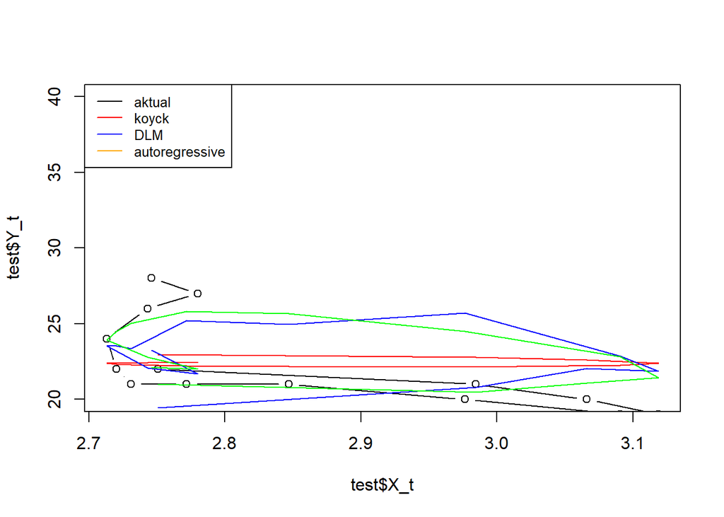

```r
par(mfrow=c(1,1))
plot(test$X_t, test$Y_t, type="b", col="black", ylim=c(20, 40))

lines(test$X_t, fore.koyck$forecasts,col="red")

lines(test$X_t, fore.dlm$forecasts,col="blue")

lines(test$X_t, fore.ardl$forecasts,col="green")

legend("topleft",c("aktual", "koyck","DLM", "autoregressive"), lty=1, col=c("black","red","blue","orange","green"), cex=0.8)
```